# Getting started with pmsims

## What pmsims does

**pmsims** estimates the **minimum sample size** needed to develop a prediction model to achieve a target level of performance **with assurance**. Rather than relying on simple rules of thumb or closed‑form formulae, pmsims uses **simulation** to:

- Generate synthetic datasets that reflect your target setting (outcome type, prevalence or $R^2$, signal vs. noise predictors);
- Fit a specified **model** (e.g., logistic regression or linear regression);
- Evaluate a chosen **performance metric** (e.g., calibration slope, AUC); and
- Trace a **learning curve** of performance as the training size increases.

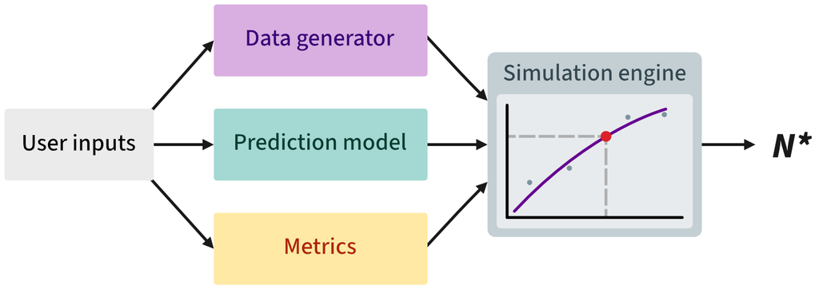

The recommended design objective is **assurance**: the **smallest** $n$ such that a high proportion of repeated studies (e.g., 80%) meet the target performance. In pmsims, this is implemented via the **20th percentile** of the simulated performance distribution at each $n$.

## Required inputs at a glance

There are three wrapper functions for binary, continuous, and survival outcomes, respectively:

- `simulate_binary()`
- `simulate_continuous()`
- `simulate_survival()`

All three functions share the same basic structure. The table below lists the key inputs.

Select wrapper

[output not shown]

> Notes:
> - `maximum_achievable_*` represents the best plausible performance with effectively unlimited data and calibrates the data generator.
> - `target_performance` is the minimum acceptable performance threshold used to determine the required sample size.
> - For reproducibility, set a random seed (`set.seed()`).

## Installation

```r
# install.packages("remotes")
# remotes::install_github("pmsims-package/pmsims")
library(pmsims)
```

## Binary-outcome example

We target the smallest *n* that meets the **assurance** criterion.

```r
set.seed(123)

binary_example <- simulate_binary(
  signal_parameters = 20,
  noise_parameters  = 0,
  predictor_type = "continuous",
  binary_predictor_prevalence = NULL,
  outcome_prevalence = 0.30,
  maximum_achievable_cstatistic = 0.80,
  model = "glm",
  metric = "calibration_slope",
  target_performance = 0.85,
  n_reps_total = 1000,
  mean_or_assurance = "assurance"
)

binary_example
```

```
#>                     ┌────────────────────────────────────────┐
#>                     │ pmsims: Sample size simulation summary │
#>                     └────────────────────────────────────────┘
#> ──────────────────────────────────── Inputs ────────────────────────────────────
#>                                Outcome : binary
#>                         Predictor type : continuous
#>                   Number of predictors : 20
#>                       Noise predictors : 0
#>                             Prevalence : 0.3
#>      Expected large-sample performance : C-statistic ('cstatistic') = 0.800
#>   Target for chosen performance metric : Calibration slope ('calib_slope') = 0.850
#>                                  Model : glm
#>                        Simulation reps : 1,000
#> ──────────────────────────────────── Results ───────────────────────────────────
#>              Final minimum sample size : 793
#>             Estimated performance at N : 0.847 (Calibration slope ('calib_slope') = 0.850)
#>            Estimated other metric at N : 0.787 (Auc ('auc'))
#>                                  Model : glm
#>                                   Mode : Assurance
#>                           Running time : 1 minute 22 seconds
#>     Assurance mode ensures the target metric is met with high probability across repeated datasets.
```

Plot the estimated learning curve and identified sample size:

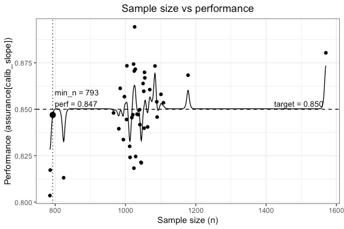

```r
plot(binary_example)
```

## Continuous-outcome example

```r
continuous_example <- simulate_continuous(
  signal_parameters = 15,
  noise_parameters = 0,
  predictor_type = "continuous",
  maximum_achievable_rsquared = 0.50,
  model = "lm",
  metric = "calibration_slope",
  target_performance = 0.90,
  n_reps_total = 1000,
  mean_or_assurance = "assurance"
)

continuous_example
```

```
#>                     ┌────────────────────────────────────────┐
#>                     │ pmsims: Sample size simulation summary │
#>                     └────────────────────────────────────────┘
#> ──────────────────────────────────── Inputs ────────────────────────────────────
#>                                Outcome : continuous
#>                         Predictor type : continuous
#>                   Number of predictors : 15
#>                       Noise predictors : 0
#>      Expected large-sample performance : R² ('r2') = 0.500
#>   Target for chosen performance metric : Calibration slope ('calib_slope') = 0.900
#>                                  Model : lm
#>                        Simulation reps : 1,000
#> ──────────────────────────────────── Results ───────────────────────────────────
#>              Final minimum sample size : 263
#>             Estimated performance at N : 0.899 (Calibration slope ('calib_slope') = 0.900)
#>            Estimated other metric at N : 0.449 (R2 ('r2'))
#>                                  Model : lm
#>                                   Mode : Assurance
#>                           Running time : 35 seconds
#>     Assurance mode ensures the target metric is met with high probability across repeated datasets.
```

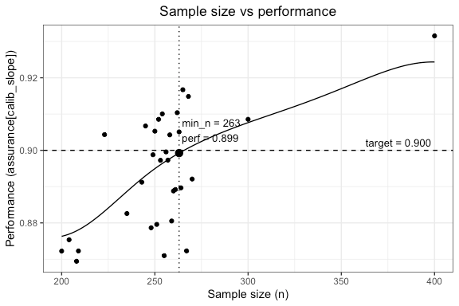

```r
plot(continuous_example)
```